# Solución de sistemas de cuaciones usando el Método Gráfico

Felipe Pérez Vargas

17/2/2021

Antes de empezar con programación lineal debemos conocer compodemos graficar un sistema de ecuaciones en dos dimensiones. Esto lo haremos usando el software libre R.

Ejemplo

Tenemos el siguiente sistema de ecuaciones
$$\begin{eqnarray}
x_{1}+3x_{2} = 6 \\
2x_{1}- x_{2} = 5 \\
3x_{1}+2x_{2} = 11
\end{eqnarray}$$
Lo que vamos a hacer a continuación es graficar las tres ecuaciones en el mismo plano, por expriencias vamos a utlizar el rengo de $x_{1}=x_{2}=[-7,7]$

Primero generamos una sucesión de números enteros con el comando seq() que esta compuesto por el límite inferior, límite superior y el paso en el que vamos a generar esos número. A continuación se muestra la instrucción:

```r
x1<-seq(-7,7,by=1);x1
```

```
##  [1] -7 -6 -5 -4 -3 -2 -1  0  1  2  3  4  5  6  7
```

Una vez que generada la secuencia de números prodemos a despejar $x_{2}$ de cada una de las ecuaciones, resultando como

$$\begin{eqnarray}
x_{21} &=& \frac{6-x_{1}}{3} \\
x_{22} &=& -5 + 2x_{1} \\
x_{23} &=& \frac{11- 3x_{1}}{2}
\end{eqnarray}$$

Ahora vamos a realizar el el gráfico de la primera ecuación. Para esto vamos a ocupar el comando plor y se explicara durante la clase

```r
# Gráficamos la primera ecuación x21

x21<-(6-x1)/3;x21
```

```
##  [1]  4.3333333  4.0000000  3.6666667  3.3333333  3.0000000  2.6666667
##  [7]  2.3333333  2.0000000  1.6666667  1.3333333  1.0000000  0.6666667
## [13]  0.3333333  0.0000000 -0.3333333
```

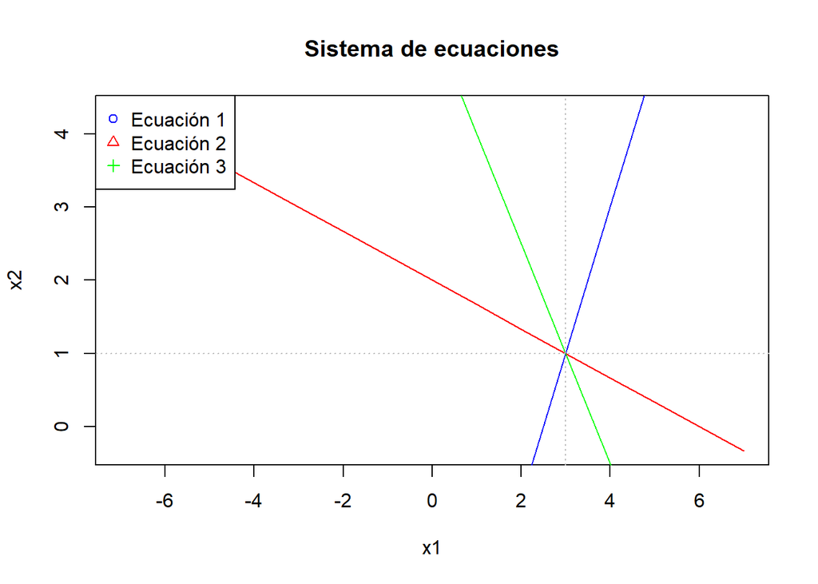

```r
plot(x1,x21, type='l', col='red', main='Sistema de ecuaciones',
     xlab = 'x1', ylab = 'x2')
# Ahora graficamos con x22
x22<- -5+2*x1
# la Agregamos con el comando lines
lines(x1,x22, col='blue')
#Ahora agregamos la tercera ecuación x23
x23<-(11-3*x1)/2
# la Agregamos con el comando lines
lines(x1,x23, col='green')
# Agregamos las líneas en el eje cero con el comando abline
abline(h=1, v=3, lty=3, col='gray')
# Podemos agregar etiquetas para cada ecuación
legend('topleft',legend=c('Ecuación 1','Ecuación 2', 'Ecuación 3'),
 pch=c(1,2, 3),col=c('blue','red','green'))
```

Graficamente podemos determinar lo solución del sistema conviertiendolo a un sistema matricial y después aplicamos el comando solve para poder encontrar la solución del sistema.

```r
# Como son tres ecuaciones y dos incógnitas solo se necesitan dos ecuaciones y se pueden
# hacer las conbinaciones 12, 13, 23
A<-matrix(c(1, 3,
            2,-1), nrow = 2, ncol = 2, byrow = TRUE)#;A
#Ahora generamos el vector b
b<-c(6,5)
S<-solve(A,b)
# Ejercicio resuelve el sistema 13 y 23 y comprueba el resultado
```

Una vez que encontramos el valor de cada una de las variable podemos agregar el punto donde el sistema tiene solución única

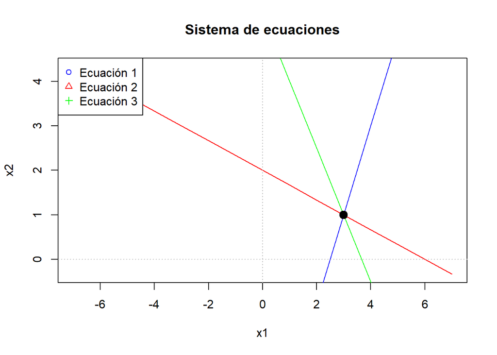

```r
# Gráficamos la primera ecuación x21
x21<-(6-x1)/3
plot(x1,x21, type='l', col='red', main='Sistema de ecuaciones',
     xlab = 'x1', ylab = 'x2')
# Ahora graficamos con x22
x22<- -5+2*x1
# la Agregamos con el comando lines
lines(x1,x22, col='blue')
#Ahora agregamos la tercera ecuación x23
x23<-(11-3*x1)/2
# la Agregamos con el comando lines
lines(x1,x23, col='green')
# Agregamos las líneas en el eje cero con el comando abline
abline(h=0, v=0, lty=3, col='gray')
# Podemos agregar etiquetas para cada ecuación
legend('topleft',legend=c('Ecuación 1','Ecuación 2', 'Ecuación 3'),
 pch=c(1,2, 3),col=c('blue','red','green'))
points(S[1], S[2], cex=1.5, pch=19)
```

Podemos hacer un grafico más especializado usando el paquete ggplot2. Para esto debemos crear un dataframe

```r
 require(ggplot2)
require(plotly)
B<-matrix(c(x1, x21,x22,x23), ncol=4)
B<-data.frame(B)
p<-ggplot(B, aes(x=x1)) +
  geom_line(aes(y=x21), color = "red") +
  geom_line(aes(y=x22), color = "blue") +
  geom_line(aes(y=x23), color = "green") +
  labs(x = "x1", y = "x2", title = 'Solución de Ecuaciones por el Método Gráfico')

ggplotly(p)
```

[interactive chart not shown]

Ahora intenta graficar las dos ecuaciones del problema planteado:

$$\begin{eqnarray}
6x_{1}+12x_{2} & \leq & 120\\
8x_{1}+4x_{2} &\leq & 64\\
x_{1}, x_{2} &\geq & 0
\end{eqnarray}$$

Paso 1

Vamos a despejar $x_{2}$ de cada una de las ecuaciones para poder graficar y resolver la ecuación